# decision making A5

LI LIPING

1 November 2018

### task1

Let’s use the A3 training dataset for this question. You can keep only two columns, X4 and X8, and the label is still y. Use the first 1500 rows for training and last 500 rows for testing. We will compare the performance of 3 different SVM kernels by “svm” function of “e1071” library. Based on the sample code provided, please Train, Tune, and Visualize SVM using the following 3 kernels: (1) Polynomial Kernel, (2) RBF Kernel, (3) Sigmoid Kernel. The initial data preparation part has been done for you in the code sample (A5-1_template.R) Using the best parameters to make predictions on the testing set. Briefly report that how is the best prediction performance across 3 kernels. How does the best model compare to other algorithms that you have tried in A3? Grading of this question is mostly based on the correctness of your code. However, if your result is far from the median performance of this class of 3 methods, penalty may be imposed.

```r
library(e1071)
library(caret)
```

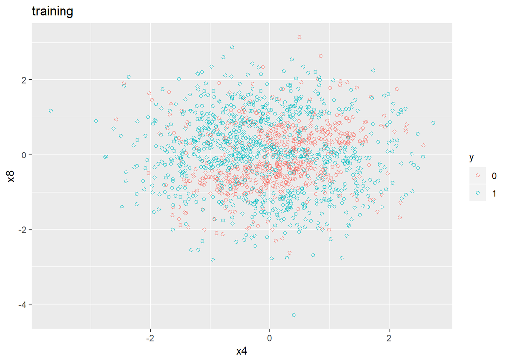

```r
train <- read.csv("data/A3_train.csv", colClasses = append(rep(c("numeric"), times = 15), "factor"))

cols <- c('x4', 'x8', 'y')

train_t <- train[1:1500, cols]
train_v <- train[1501:2000, cols]

# Plot to see how data look like
ggplot(train_t, aes(x = x4, y = x8, color = y)) + geom_point(shape = 1) + ggtitle("training")
```

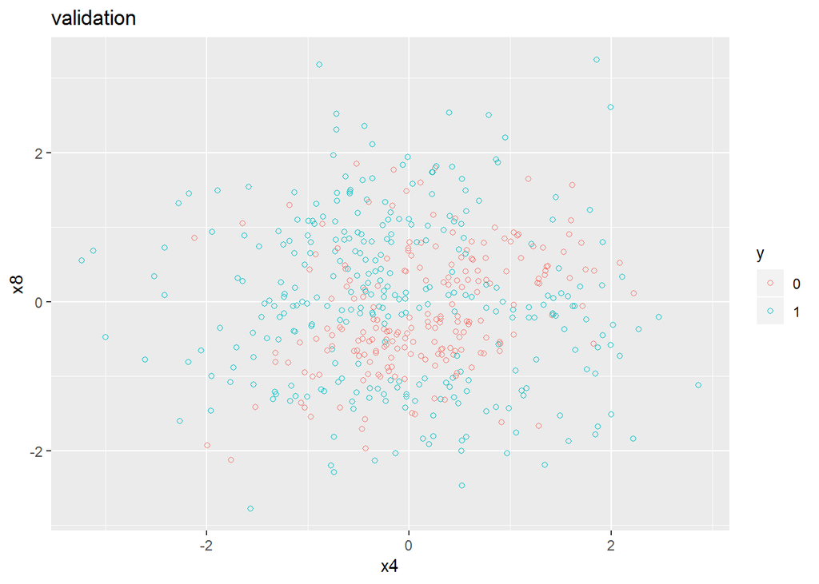

```r
ggplot(train_v, aes(x = x4, y = x8, color = y)) + geom_point(shape = 1) + ggtitle("validation")
```

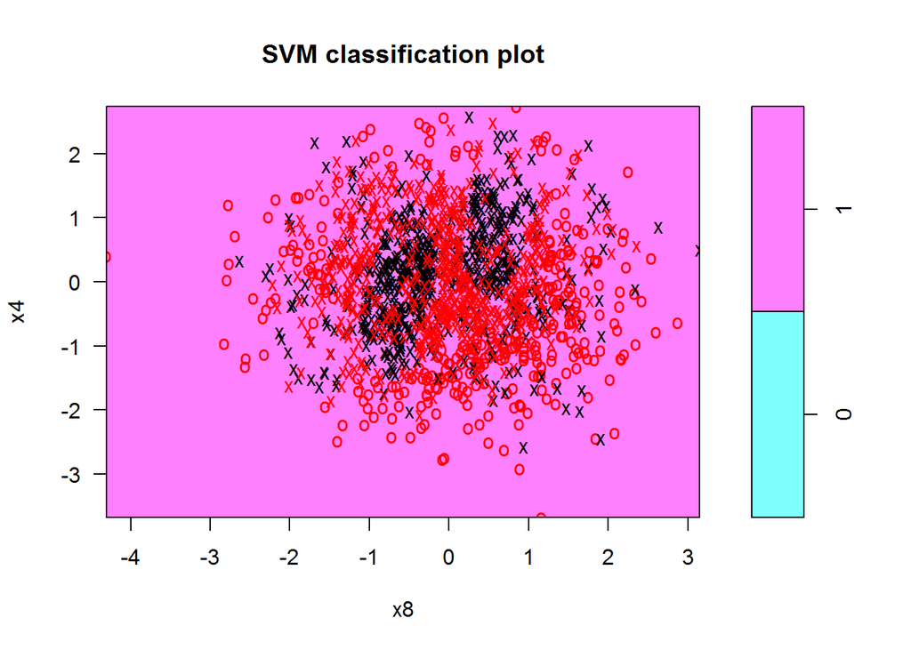

```r
#linear kernel
model.linear <- svm(y ~ ., data=train_t, kernel = 'linear', cost = 1)
plot(model.linear, train_t)
```

```r
pred.linear <-  predict(model.linear, train_v)
confusionMatrix(pred.linear, train_v$y)
```

```
## Confusion Matrix and Statistics
##
##           Reference
## Prediction   0   1
##          0   0   0
##          1 204 296
##
##                Accuracy : 0.592
##                  95% CI : (0.5475, 0.6354)
##     No Information Rate : 0.592
##     P-Value [Acc > NIR] : 0.5193
##
##                   Kappa : 0
##  Mcnemar's Test P-Value : <2e-16
##
##             Sensitivity : 0.000
##             Specificity : 1.000
##          Pos Pred Value :   NaN
##          Neg Pred Value : 0.592
##              Prevalence : 0.408
##          Detection Rate : 0.000
##    Detection Prevalence : 0.000
##       Balanced Accuracy : 0.500
##
##        'Positive' Class : 0
##
```

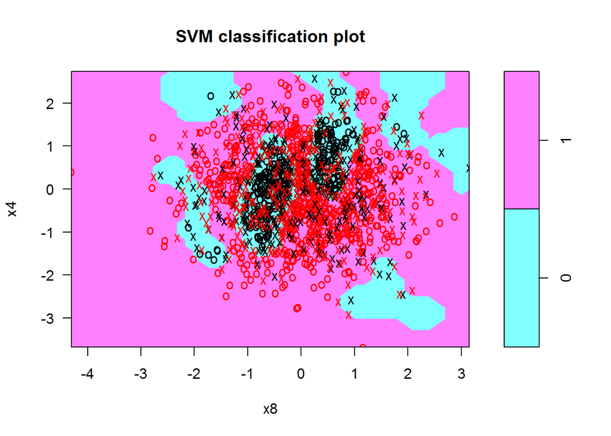

```r
#Polynomial Kernel
model.poly <- svm(y ~ ., data=train_t, kernel = 'polynomial', gama=1,cost=1)#train
tune.poly <- tune(svm,y~.,data=train_t,ranges=list(cost=c(.0001,.001,.01,.1,10,100,1000),gamma=c(.01,.1,.5,1,2,3,4),degree=c(2,3,4)))#tune
plot(tune.poly$best.model,train_t)#visualize
```

```r
#prediction using best model
pred.poly <-  predict(tune.poly$best.model, train_v)
confusionMatrix(pred.poly, train_v$y)
```

```
## Confusion Matrix and Statistics
##
##           Reference
## Prediction   0   1
##          0 143  37
##          1  61 259
##
##                Accuracy : 0.804
##                  95% CI : (0.7664, 0.8379)
##     No Information Rate : 0.592
##     P-Value [Acc > NIR] : < 2e-16
##
##                   Kappa : 0.5867
##  Mcnemar's Test P-Value : 0.02016
##
##             Sensitivity : 0.7010
##             Specificity : 0.8750
##          Pos Pred Value : 0.7944
##          Neg Pred Value : 0.8094
##              Prevalence : 0.4080
##          Detection Rate : 0.2860
##    Detection Prevalence : 0.3600
##       Balanced Accuracy : 0.7880
##
##        'Positive' Class : 0
##
```

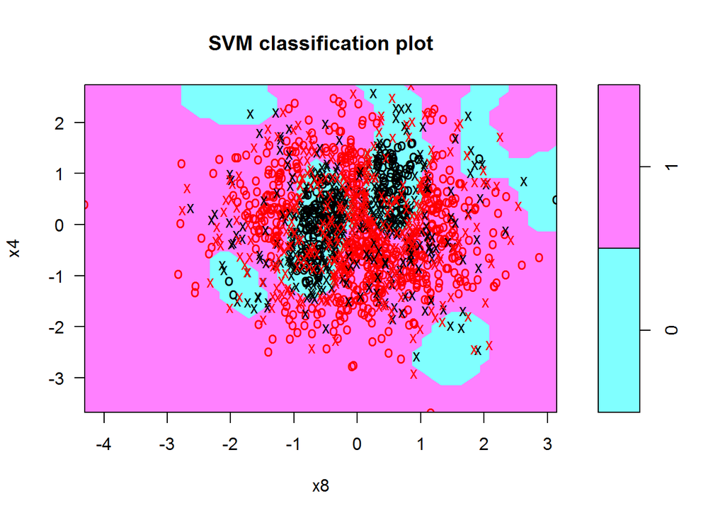

```r
#RBF Kernel
model.rbf <- svm(y ~ ., data=train_t, kernel = 'radial',cost=1)#train
tune.rbf <- tune(svm,y~.,data=train_t,kernel='radial',ranges=list(cost=c(.0001,.001,.01,.1,10,100,1000),gamma=c(.01,.1,.5,1,2,3,4)))#tune
plot(tune.rbf$best.model,train_t)#visualize
```

```r
#prediction using best model
pred.rbf <-  predict(tune.rbf$best.model, train_v)
confusionMatrix(pred.rbf, train_v$y)
```

```
## Confusion Matrix and Statistics
##
##           Reference
## Prediction   0   1
##          0 136  23
##          1  68 273
##
##                Accuracy : 0.818
##                  95% CI : (0.7813, 0.8509)
##     No Information Rate : 0.592
##     P-Value [Acc > NIR] : < 2.2e-16
##
##                   Kappa : 0.6099
##  Mcnemar's Test P-Value : 3.979e-06
##
##             Sensitivity : 0.6667
##             Specificity : 0.9223
##          Pos Pred Value : 0.8553
##          Neg Pred Value : 0.8006
##              Prevalence : 0.4080
##          Detection Rate : 0.2720
##    Detection Prevalence : 0.3180
##       Balanced Accuracy : 0.7945
##
##        'Positive' Class : 0
##
```

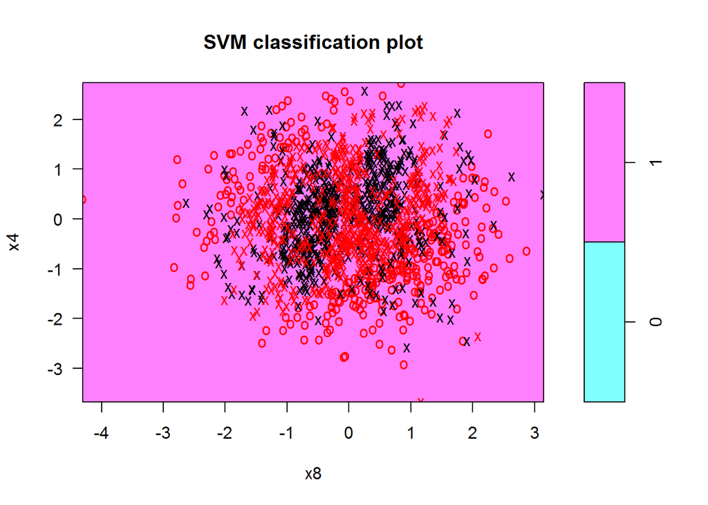

```r
#Sigmoid Kernel
model.sig <- svm(y ~ ., data=train_t, kernel = 'sigmoid',cost=1)#train
tune.sig <- tune(svm, y~.,data=train_t, kernel="sigmoid",ranges=list(coef0= (-1:1), gamma=10^(-6:-2),cost=10^(0:3)))#tune
plot(tune.sig$best.model,train_t)#visualize
```

```r
#prediction using best model
pred.sig <-  predict(tune.sig$best.model, train_v)
confusionMatrix(pred.sig, train_v$y)
```

```
## Confusion Matrix and Statistics
##
##           Reference
## Prediction   0   1
##          0   0   0
##          1 204 296
##
##                Accuracy : 0.592
##                  95% CI : (0.5475, 0.6354)
##     No Information Rate : 0.592
##     P-Value [Acc > NIR] : 0.5193
##
##                   Kappa : 0
##  Mcnemar's Test P-Value : <2e-16
##
##             Sensitivity : 0.000
##             Specificity : 1.000
##          Pos Pred Value :   NaN
##          Neg Pred Value : 0.592
##              Prevalence : 0.408
##          Detection Rate : 0.000
##    Detection Prevalence : 0.000
##       Balanced Accuracy : 0.500
##
##        'Positive' Class : 0
##
```

### task2

The dataset is the HomeCredit dataset from Kaggle.com. Please use the pre-processed dataset uploaded on IVLE for this assignment and a code sample (A5-2_template.R) is provided. The files are named: - application_v3.csv: This is your main data file for this question - column_descriptions.xlsx: This is an Excel spreadsheet that describes the columns (2-1) Please try using XGBoost as the baseline model to predict “TARGET”, which is the customer will default or not. The performance metric is AUC. (2-2) Please try under-sampling, over-sampling, under- and over-sampling together, and SMOTE with the XGBoost. Report which method gives you the best prediction performance. Similarly, if your best performance is too poor, penalty may be imposed on this question.

```r
library(caret)
library(ROCR)
set.seed(5152)
#load data
data <- read.csv("data/application_v3.csv")
data$TARGET <- factor(data$TARGET)
levels(data$TARGET) <- c("OTHER", "DIFFICULTY")
#create the train data and test data
train_idx <- createDataPartition(data$TARGET, p = 0.7, list = FALSE)
train <- data[train_idx, ]
test  <- data[-train_idx, ]

#using XGBoost as the baseline model to predict "TARGET"
ctrl_base <- trainControl(method = "cv", number = 5)
model.baseline <- train(TARGET ~ ., data = train, method = "xgbTree", metric = "Accuracy", trControl = ctrl_base)
pred.base <- predict(model.baseline, test,type = "prob")
performance(prediction(pred.base$OTHER,test$TARGET),"auc")@y.values
```

```
## [[1]]
## [1] 0.5870089
```

```r
#cm.base <- confusionMatrix(pred.base, test$TARGET)

# Under-sampling by Caret
ctrl_under <- trainControl(method = "cv", number = 5, sampling = "down")
# values supported in Caret sampling are "none", "down", "up", "smote", or "rose"
model.under <- train(TARGET ~ ., data = train, method = "xgbTree", metric = "Accuracy", trControl = ctrl_under)
pred.under <- predict(model.under, test,type = "prob")
performance(prediction(pred.under$OTHER,test$TARGET),"auc")@y.values
```

```
## [[1]]
## [1] 0.5782977
```

```r
#cm.under <- confusionMatrix(pred.under, test$TARGET)

#Over-sampling by Caret
ctrl_over <- trainControl(method = "cv", number = 5, sampling = "up")
# values supported in Caret sampling are "none", "down", "up", "smote", or "rose"
model.over <- train(TARGET ~ ., data = train, method = "xgbTree", metric = "Accuracy", trControl = ctrl_over)
pred.over <- predict(model.over, test,type = "prob")
performance(prediction(pred.over$OTHER,test$TARGET),"auc")@y.values
```

```
## [[1]]
## [1] 0.5629816
```

```r
#cm.over <- confusionMatrix(pred.over, test$TARGET)

# Under-sampling and Over-sampling together by Caret
ctrl_both <- trainControl(method = "cv", number = 5, sampling =c("down","up"))
# values supported in Caret sampling are "none", "down", "up", "smote", or "rose"
model.both <- train(TARGET ~ ., data = train, method = "xgbTree", metric = "Accuracy", trControl = ctrl_over)
pred.both <- predict(model.both, test,type = "prob")
performance(prediction(pred.over$OTHER,test$TARGET),"auc")@y.values
```

```
## [[1]]
## [1] 0.5629816
```

```r
#cm.both <- confusionMatrix(pred.both, test$TARGET)

# SMOTE by Caret
ctrl_smote <- trainControl(method = "cv", number = 5, sampling = "smote")
set.seed(42)
model.smote <- train(TARGET ~ ., data = train, method = "xgbTree", metric = "Accuracy", trControl = ctrl_smote)
pred.smote <- predict(model.smote, test,type = "prob")
performance(prediction(pred.smote$OTHER,test$TARGET),"auc")@y.values
```

```
## [[1]]
## [1] 0.5666055
```

```r
#cm.smote <- confusionMatrix(pred.smote, test$TARGET)
```